# Project: Investigate TMDB Movies Dataset

- Introduction
- Data Wrangling
- Exploratory Data Analysis
- Conclusions

## Introduction

The TMDb movie dataset from kaggle was selected for this project. This dataset contains information about 10,000 movies collected from The Movie Database (TMDb), including metrics about how successful these movies are (e.g. popularity, revenue and vote-average) as well as some basic information of the movie (e.g. cast, director, keywords, runtime, genres, etc.). The purpose of this project is to go through the general data analysis process and identify properties that are associated with the success of movies as well as some interesting trends, such as genre trends, over years. I am going to explore the dataset by answering the following research questions:

Part One -- General Explore:

> 1. Which genre/production company/director has the highest release of movies?
> 2. What's the total budget from year to year?
> 3. What's the total revenue from year to year?
> 4. What's the total profit from year to year?

Part Two -- Analysis of Categorical Variables:

> 1. Which genres have the highest popularity/vote-rating/revenue/profit?
> 2. Which directors direct the movies that have the highest popularity/vote-rating/revenue/profit?
> 3. Which production companies produce movies that have the highest popularity/vote-rating/revenue/profit?

Part Three -- Analysis of Numerical Variables:

> 1. What kinds of properties are associated with high revenues?
> 2. What kinds of properties are associated with high profit?

```python
# Import packages
import pandas as pd
import numpy as np
import matplotlib.pyplot as plt
from pandas import Series, DataFrame
import csv
import seaborn as sns
%matplotlib inline
```

## Data Wrangling

### General Properties

```python
# Load the dataset and print out a few lines. Perform operations to inspect data
#   types and look for instances of missing or possibly errant data.
df = pd.read_csv('tmdb-movies.csv')
df.head()
```

|  | id | imdb_id | popularity | budget | revenue | original_title | cast | homepage | director | tagline | ... | overview | runtime | genres | production_companies | release_date | vote_count | vote_average | release_year | budget_adj | revenue_adj |
| --- | --- | --- | --- | --- | --- | --- | --- | --- | --- | --- | --- | --- | --- | --- | --- | --- | --- | --- | --- | --- | --- |
| 0 | 135397 | tt0369610 | 32.985763 | 150000000 | 1513528810 | Jurassic World | Chris Pratt\|Bryce Dallas Howard\|Irrfan Khan\|Vi... | http://www.jurassicworld.com/ | Colin Trevorrow | The park is open. | ... | Twenty-two years after the events of Jurassic ... | 124 | Action\|Adventure\|Science Fiction\|Thriller | Universal Studios\|Amblin Entertainment\|Legenda... | 6/9/15 | 5562 | 6.5 | 2015 | 1.379999e+08 | 1.392446e+09 |
| 1 | 76341 | tt1392190 | 28.419936 | 150000000 | 378436354 | Mad Max: Fury Road | Tom Hardy\|Charlize Theron\|Hugh Keays-Byrne\|Nic... | http://www.madmaxmovie.com/ | George Miller | What a Lovely Day. | ... | An apocalyptic story set in the furthest reach... | 120 | Action\|Adventure\|Science Fiction\|Thriller | Village Roadshow Pictures\|Kennedy Miller Produ... | 5/13/15 | 6185 | 7.1 | 2015 | 1.379999e+08 | 3.481613e+08 |
| 2 | 262500 | tt2908446 | 13.112507 | 110000000 | 295238201 | Insurgent | Shailene Woodley\|Theo James\|Kate Winslet\|Ansel... | http://www.thedivergentseries.movie/#insurgent | Robert Schwentke | One Choice Can Destroy You | ... | Beatrice Prior must confront her inner demons ... | 119 | Adventure\|Science Fiction\|Thriller | Summit Entertainment\|Mandeville Films\|Red Wago... | 3/18/15 | 2480 | 6.3 | 2015 | 1.012000e+08 | 2.716190e+08 |
| 3 | 140607 | tt2488496 | 11.173104 | 200000000 | 2068178225 | Star Wars: The Force Awakens | Harrison Ford\|Mark Hamill\|Carrie Fisher\|Adam D... | http://www.starwars.com/films/star-wars-episod... | J.J. Abrams | Every generation has a story. | ... | Thirty years after defeating the Galactic Empi... | 136 | Action\|Adventure\|Science Fiction\|Fantasy | Lucasfilm\|Truenorth Productions\|Bad Robot | 12/15/15 | 5292 | 7.5 | 2015 | 1.839999e+08 | 1.902723e+09 |
| 4 | 168259 | tt2820852 | 9.335014 | 190000000 | 1506249360 | Furious 7 | Vin Diesel\|Paul Walker\|Jason Statham\|Michelle ... | http://www.furious7.com/ | James Wan | Vengeance Hits Home | ... | Deckard Shaw seeks revenge against Dominic Tor... | 137 | Action\|Crime\|Thriller | Universal Pictures\|Original Film\|Media Rights ... | 4/1/15 | 2947 | 7.3 | 2015 | 1.747999e+08 | 1.385749e+09 |

5 rows × 21 columns

```python
df.info()
```

```
<class 'pandas.core.frame.DataFrame'>
RangeIndex: 10866 entries, 0 to 10865
Data columns (total 21 columns):
id                      10866 non-null int64
imdb_id                 10856 non-null object
popularity              10866 non-null float64
budget                  10866 non-null int64
revenue                 10866 non-null int64
original_title          10866 non-null object
cast                    10790 non-null object
homepage                2936 non-null object
director                10822 non-null object
tagline                 8042 non-null object
keywords                9373 non-null object
overview                10862 non-null object
runtime                 10866 non-null int64
genres                  10843 non-null object
production_companies    9836 non-null object
release_date            10866 non-null object
vote_count              10866 non-null int64
vote_average            10866 non-null float64
release_year            10866 non-null int64
budget_adj              10866 non-null float64
revenue_adj             10866 non-null float64
dtypes: float64(4), int64(6), object(11)
memory usage: 1.7+ MB
```

```python
df.isnull().sum()
```

```
id                         0
imdb_id                   10
popularity                 0
budget                     0
revenue                    0
original_title             0
cast                      76
homepage                7930
director                  44
tagline                 2824
keywords                1493
overview                   4
runtime                    0
genres                    23
production_companies    1030
release_date               0
vote_count                 0
vote_average               0
release_year               0
budget_adj                 0
revenue_adj                0
dtype: int64
```

### Data Cleaning

> Step 1 -- Check for missing data, only keep columns that are needed for analysis. Check and drop duplicates.  
> Step 2 -- Identify and modify rows which contain incorrect or inappropriate values.  
> Step 3 -- Create variable "profit".  
> Step 4 -- Split "genres", "production_companies" and "director".

#### Step 1 -- Check for missing data, only keep columns that are needed for analysis. Check and drop duplicates.

An overview of the dataset shows that the data types are appropriate. But there is a significant amount of missing data for columns such as homepage, tagline, keywords, and production_companies. We decides to drop "homepage" and "tagline" which are of irrelevant in answering the research questions, while keeping "keywords" and "production_companies" for potential analysis.

```python
df.drop(['homepage', 'tagline'], axis = 1, inplace=True)
df.head()
```

|  | id | imdb_id | popularity | budget | revenue | original_title | cast | director | keywords | overview | runtime | genres | production_companies | release_date | vote_count | vote_average | release_year | budget_adj | revenue_adj |
| --- | --- | --- | --- | --- | --- | --- | --- | --- | --- | --- | --- | --- | --- | --- | --- | --- | --- | --- | --- |
| 0 | 135397 | tt0369610 | 32.985763 | 150000000 | 1513528810 | Jurassic World | Chris Pratt\|Bryce Dallas Howard\|Irrfan Khan\|Vi... | Colin Trevorrow | monster\|dna\|tyrannosaurus rex\|velociraptor\|island | Twenty-two years after the events of Jurassic ... | 124 | Action\|Adventure\|Science Fiction\|Thriller | Universal Studios\|Amblin Entertainment\|Legenda... | 6/9/15 | 5562 | 6.5 | 2015 | 1.379999e+08 | 1.392446e+09 |
| 1 | 76341 | tt1392190 | 28.419936 | 150000000 | 378436354 | Mad Max: Fury Road | Tom Hardy\|Charlize Theron\|Hugh Keays-Byrne\|Nic... | George Miller | future\|chase\|post-apocalyptic\|dystopia\|australia | An apocalyptic story set in the furthest reach... | 120 | Action\|Adventure\|Science Fiction\|Thriller | Village Roadshow Pictures\|Kennedy Miller Produ... | 5/13/15 | 6185 | 7.1 | 2015 | 1.379999e+08 | 3.481613e+08 |
| 2 | 262500 | tt2908446 | 13.112507 | 110000000 | 295238201 | Insurgent | Shailene Woodley\|Theo James\|Kate Winslet\|Ansel... | Robert Schwentke | based on novel\|revolution\|dystopia\|sequel\|dyst... | Beatrice Prior must confront her inner demons ... | 119 | Adventure\|Science Fiction\|Thriller | Summit Entertainment\|Mandeville Films\|Red Wago... | 3/18/15 | 2480 | 6.3 | 2015 | 1.012000e+08 | 2.716190e+08 |
| 3 | 140607 | tt2488496 | 11.173104 | 200000000 | 2068178225 | Star Wars: The Force Awakens | Harrison Ford\|Mark Hamill\|Carrie Fisher\|Adam D... | J.J. Abrams | android\|spaceship\|jedi\|space opera\|3d | Thirty years after defeating the Galactic Empi... | 136 | Action\|Adventure\|Science Fiction\|Fantasy | Lucasfilm\|Truenorth Productions\|Bad Robot | 12/15/15 | 5292 | 7.5 | 2015 | 1.839999e+08 | 1.902723e+09 |
| 4 | 168259 | tt2820852 | 9.335014 | 190000000 | 1506249360 | Furious 7 | Vin Diesel\|Paul Walker\|Jason Statham\|Michelle ... | James Wan | car race\|speed\|revenge\|suspense\|car | Deckard Shaw seeks revenge against Dominic Tor... | 137 | Action\|Crime\|Thriller | Universal Pictures\|Original Film\|Media Rights ... | 4/1/15 | 2947 | 7.3 | 2015 | 1.747999e+08 | 1.385749e+09 |

The dataset contains "budget", "revenue", "budget_adj" and "revenue_adj", where the later two columns - "budget_adj" and "revenue_adj" show the budget and revenue of the associated movie in terms of 2010 dollars, accounting for inflation over time. The adjusted budget and revenue are more accurate in comparing the profit over year. Therefore, I decide to drop the redundent columns - "budget" and "revenue", and keep only "budget_adj" and "revenue_adj".

```python
df.drop(['budget', 'revenue'], axis = 1, inplace=True)
df.head()
```

|  | id | imdb_id | popularity | original_title | cast | director | keywords | overview | runtime | genres | production_companies | release_date | vote_count | vote_average | release_year | budget_adj | revenue_adj |
| --- | --- | --- | --- | --- | --- | --- | --- | --- | --- | --- | --- | --- | --- | --- | --- | --- | --- |
| 0 | 135397 | tt0369610 | 32.985763 | Jurassic World | Chris Pratt\|Bryce Dallas Howard\|Irrfan Khan\|Vi... | Colin Trevorrow | monster\|dna\|tyrannosaurus rex\|velociraptor\|island | Twenty-two years after the events of Jurassic ... | 124 | Action\|Adventure\|Science Fiction\|Thriller | Universal Studios\|Amblin Entertainment\|Legenda... | 6/9/15 | 5562 | 6.5 | 2015 | 1.379999e+08 | 1.392446e+09 |
| 1 | 76341 | tt1392190 | 28.419936 | Mad Max: Fury Road | Tom Hardy\|Charlize Theron\|Hugh Keays-Byrne\|Nic... | George Miller | future\|chase\|post-apocalyptic\|dystopia\|australia | An apocalyptic story set in the furthest reach... | 120 | Action\|Adventure\|Science Fiction\|Thriller | Village Roadshow Pictures\|Kennedy Miller Produ... | 5/13/15 | 6185 | 7.1 | 2015 | 1.379999e+08 | 3.481613e+08 |
| 2 | 262500 | tt2908446 | 13.112507 | Insurgent | Shailene Woodley\|Theo James\|Kate Winslet\|Ansel... | Robert Schwentke | based on novel\|revolution\|dystopia\|sequel\|dyst... | Beatrice Prior must confront her inner demons ... | 119 | Adventure\|Science Fiction\|Thriller | Summit Entertainment\|Mandeville Films\|Red Wago... | 3/18/15 | 2480 | 6.3 | 2015 | 1.012000e+08 | 2.716190e+08 |
| 3 | 140607 | tt2488496 | 11.173104 | Star Wars: The Force Awakens | Harrison Ford\|Mark Hamill\|Carrie Fisher\|Adam D... | J.J. Abrams | android\|spaceship\|jedi\|space opera\|3d | Thirty years after defeating the Galactic Empi... | 136 | Action\|Adventure\|Science Fiction\|Fantasy | Lucasfilm\|Truenorth Productions\|Bad Robot | 12/15/15 | 5292 | 7.5 | 2015 | 1.839999e+08 | 1.902723e+09 |
| 4 | 168259 | tt2820852 | 9.335014 | Furious 7 | Vin Diesel\|Paul Walker\|Jason Statham\|Michelle ... | James Wan | car race\|speed\|revenge\|suspense\|car | Deckard Shaw seeks revenge against Dominic Tor... | 137 | Action\|Crime\|Thriller | Universal Pictures\|Original Film\|Media Rights ... | 4/1/15 | 2947 | 7.3 | 2015 | 1.747999e+08 | 1.385749e+09 |

```python
# Check dedupe data
print(df.duplicated().sum())
```

```
1
```

```python
# drop duplicates and check the number of duplicated again to confirm dedupe
df.drop_duplicates(inplace=True)
print(df.duplicated().sum())
```

```
0
```

```python
#print concise summery of the dataset
df.describe()
```

|  | id | popularity | runtime | vote_count | vote_average | release_year | budget_adj | revenue_adj |
| --- | --- | --- | --- | --- | --- | --- | --- | --- |
| count | 10865.000000 | 10865.000000 | 10865.000000 | 10865.000000 | 10865.000000 | 10865.000000 | 1.086500e+04 | 1.086500e+04 |
| mean | 66066.374413 | 0.646446 | 102.071790 | 217.399632 | 5.975012 | 2001.321859 | 1.754989e+07 | 5.136900e+07 |
| std | 92134.091971 | 1.000231 | 31.382701 | 575.644627 | 0.935138 | 12.813260 | 3.430753e+07 | 1.446383e+08 |
| min | 5.000000 | 0.000065 | 0.000000 | 10.000000 | 1.500000 | 1960.000000 | 0.000000e+00 | 0.000000e+00 |
| 25% | 10596.000000 | 0.207575 | 90.000000 | 17.000000 | 5.400000 | 1995.000000 | 0.000000e+00 | 0.000000e+00 |
| 50% | 20662.000000 | 0.383831 | 99.000000 | 38.000000 | 6.000000 | 2006.000000 | 0.000000e+00 | 0.000000e+00 |
| 75% | 75612.000000 | 0.713857 | 111.000000 | 146.000000 | 6.600000 | 2011.000000 | 2.085325e+07 | 3.370173e+07 |
| max | 417859.000000 | 32.985763 | 900.000000 | 9767.000000 | 9.200000 | 2015.000000 | 4.250000e+08 | 2.827124e+09 |

```python
# Movies where the budget have '0' value
df_zero_budget_adj = df.query('budget_adj == 0')
df_zero_budget_adj.shape
```

```
(5696, 17)
```

```python
# Movies where the revenue have '0' value
df_zero_revenue_adj = df.query('revenue_adj == 0')
df_zero_revenue_adj.shape
```

```
(6016, 17)
```

```python
df_zero_budget_adj.head()
```

|  | id | imdb_id | popularity | original_title | cast | director | keywords | overview | runtime | genres | production_companies | release_date | vote_count | vote_average | release_year | budget_adj | revenue_adj |
| --- | --- | --- | --- | --- | --- | --- | --- | --- | --- | --- | --- | --- | --- | --- | --- | --- | --- |
| 30 | 280996 | tt3168230 | 3.927333 | Mr. Holmes | Ian McKellen\|Milo Parker\|Laura Linney\|Hattie M... | Bill Condon | london\|detective\|sherlock holmes | The story is set in 1947, following a long-ret... | 103 | Mystery\|Drama | BBC Films\|See-Saw Films\|FilmNation Entertainme... | 6/19/15 | 425 | 6.4 | 2015 | 0.0 | 2.700677e+07 |
| 36 | 339527 | tt1291570 | 3.358321 | Solace | Abbie Cornish\|Jeffrey Dean Morgan\|Colin Farrel... | Afonso Poyart | thriller\|serial killer\|psychic\|fbi agent\|intrigue | A psychic doctor, John Clancy, works with an F... | 101 | Crime\|Drama\|Mystery | Eden Rock Media\|FilmNation Entertainment\|Flynn... | 9/3/15 | 474 | 6.2 | 2015 | 0.0 | 2.056620e+07 |
| 72 | 284289 | tt2911668 | 2.272044 | Beyond the Reach | Michael Douglas\|Jeremy Irvine\|Hanna Mangan Law... | Jean-Baptiste Léonetti | desert\|hunting | A high-rolling corporate shark and his impover... | 95 | Thriller | Furthur Films | 4/17/15 | 81 | 5.5 | 2015 | 0.0 | 4.222338e+04 |
| 74 | 347096 | tt3478232 | 2.165433 | Mythica: The Darkspore | Melanie Stone\|Kevin Sorbo\|Adam Johnson\|Jake St... | Anne K. Black | sword\|magic\|sorcery\|necromancer\|woman director | When Teela’s sister is murdered and a powerf... | 108 | Action\|Adventure\|Fantasy | Arrowstorm Entertainment | 6/24/15 | 27 | 5.1 | 2015 | 0.0 | 0.000000e+00 |
| 75 | 308369 | tt2582496 | 2.141506 | Me and Earl and the Dying Girl | Thomas Mann\|RJ Cyler\|Olivia Cooke\|Connie Britt... | Alfonso Gomez-Rejon | tattoo\|high school\|leukemia\|friends\|parody | Greg is coasting through senior year of high s... | 105 | Comedy\|Drama | Indian Paintbrush | 6/12/15 | 569 | 7.7 | 2015 | 0.0 | 0.000000e+00 |

#### Step 2 -- Identify and modify rows which contain incorrect or inappropriate values.

```python
# Replace zero values with null values in the budget and revenue column.
df['budget_adj'] = df['budget_adj'].replace(0, np.NaN)
df['revenue_adj'] = df['revenue_adj'].replace(0, np.NaN)
# see if nulls are added in budget and revenue columns
df.info()
```

```
<class 'pandas.core.frame.DataFrame'>
Int64Index: 10865 entries, 0 to 10865
Data columns (total 17 columns):
id                      10865 non-null int64
imdb_id                 10855 non-null object
popularity              10865 non-null float64
original_title          10865 non-null object
cast                    10789 non-null object
director                10821 non-null object
keywords                9372 non-null object
overview                10861 non-null object
runtime                 10865 non-null int64
genres                  10842 non-null object
production_companies    9835 non-null object
release_date            10865 non-null object
vote_count              10865 non-null int64
vote_average            10865 non-null float64
release_year            10865 non-null int64
budget_adj              5169 non-null float64
revenue_adj             4849 non-null float64
dtypes: float64(4), int64(4), object(9)
memory usage: 1.5+ MB
```

#### Step 3 -- Create variable "profit"

Profit is the most straighforward variable to reflect the success of movies, thus will be calculated and added to the dataset.

```python
# Calculate Profit for each of the movie
# Add a new column "profit_adj" to the end of the dataset
df['profit_adj'] = df['revenue_adj'] - df['budget_adj']
df.head()
```

|  | id | imdb_id | popularity | original_title | cast | director | keywords | overview | runtime | genres | production_companies | release_date | vote_count | vote_average | release_year | budget_adj | revenue_adj | profit_adj |
| --- | --- | --- | --- | --- | --- | --- | --- | --- | --- | --- | --- | --- | --- | --- | --- | --- | --- | --- |
| 0 | 135397 | tt0369610 | 32.985763 | Jurassic World | Chris Pratt\|Bryce Dallas Howard\|Irrfan Khan\|Vi... | Colin Trevorrow | monster\|dna\|tyrannosaurus rex\|velociraptor\|island | Twenty-two years after the events of Jurassic ... | 124 | Action\|Adventure\|Science Fiction\|Thriller | Universal Studios\|Amblin Entertainment\|Legenda... | 6/9/15 | 5562 | 6.5 | 2015 | 1.379999e+08 | 1.392446e+09 | 1.254446e+09 |
| 1 | 76341 | tt1392190 | 28.419936 | Mad Max: Fury Road | Tom Hardy\|Charlize Theron\|Hugh Keays-Byrne\|Nic... | George Miller | future\|chase\|post-apocalyptic\|dystopia\|australia | An apocalyptic story set in the furthest reach... | 120 | Action\|Adventure\|Science Fiction\|Thriller | Village Roadshow Pictures\|Kennedy Miller Produ... | 5/13/15 | 6185 | 7.1 | 2015 | 1.379999e+08 | 3.481613e+08 | 2.101614e+08 |
| 2 | 262500 | tt2908446 | 13.112507 | Insurgent | Shailene Woodley\|Theo James\|Kate Winslet\|Ansel... | Robert Schwentke | based on novel\|revolution\|dystopia\|sequel\|dyst... | Beatrice Prior must confront her inner demons ... | 119 | Adventure\|Science Fiction\|Thriller | Summit Entertainment\|Mandeville Films\|Red Wago... | 3/18/15 | 2480 | 6.3 | 2015 | 1.012000e+08 | 2.716190e+08 | 1.704191e+08 |
| 3 | 140607 | tt2488496 | 11.173104 | Star Wars: The Force Awakens | Harrison Ford\|Mark Hamill\|Carrie Fisher\|Adam D... | J.J. Abrams | android\|spaceship\|jedi\|space opera\|3d | Thirty years after defeating the Galactic Empi... | 136 | Action\|Adventure\|Science Fiction\|Fantasy | Lucasfilm\|Truenorth Productions\|Bad Robot | 12/15/15 | 5292 | 7.5 | 2015 | 1.839999e+08 | 1.902723e+09 | 1.718723e+09 |
| 4 | 168259 | tt2820852 | 9.335014 | Furious 7 | Vin Diesel\|Paul Walker\|Jason Statham\|Michelle ... | James Wan | car race\|speed\|revenge\|suspense\|car | Deckard Shaw seeks revenge against Dominic Tor... | 137 | Action\|Crime\|Thriller | Universal Pictures\|Original Film\|Media Rights ... | 4/1/15 | 2947 | 7.3 | 2015 | 1.747999e+08 | 1.385749e+09 | 1.210949e+09 |

#### Step 4 -- Split "genres", "production_companies" and "director".

##### Split Genres

```python
# Split genres and create a new entry for each of the genre a movie falls into
df_genres = df.copy()
s = df_genres['genres'].str.split('|').apply(Series, 1).stack()
s.index = s.index.droplevel(-1)
s.name = 'genres'
del df_genres['genres']
df_split_genres = df_genres.join(s)
# Check results
df_split_genres.head()
```

|  | id | imdb_id | popularity | original_title | cast | director | keywords | overview | runtime | production_companies | release_date | vote_count | vote_average | release_year | budget_adj | revenue_adj | profit_adj | genres |
| --- | --- | --- | --- | --- | --- | --- | --- | --- | --- | --- | --- | --- | --- | --- | --- | --- | --- | --- |
| 0 | 135397 | tt0369610 | 32.985763 | Jurassic World | Chris Pratt\|Bryce Dallas Howard\|Irrfan Khan\|Vi... | Colin Trevorrow | monster\|dna\|tyrannosaurus rex\|velociraptor\|island | Twenty-two years after the events of Jurassic ... | 124 | Universal Studios\|Amblin Entertainment\|Legenda... | 6/9/15 | 5562 | 6.5 | 2015 | 1.379999e+08 | 1.392446e+09 | 1.254446e+09 | Action |
| 0 | 135397 | tt0369610 | 32.985763 | Jurassic World | Chris Pratt\|Bryce Dallas Howard\|Irrfan Khan\|Vi... | Colin Trevorrow | monster\|dna\|tyrannosaurus rex\|velociraptor\|island | Twenty-two years after the events of Jurassic ... | 124 | Universal Studios\|Amblin Entertainment\|Legenda... | 6/9/15 | 5562 | 6.5 | 2015 | 1.379999e+08 | 1.392446e+09 | 1.254446e+09 | Adventure |
| 0 | 135397 | tt0369610 | 32.985763 | Jurassic World | Chris Pratt\|Bryce Dallas Howard\|Irrfan Khan\|Vi... | Colin Trevorrow | monster\|dna\|tyrannosaurus rex\|velociraptor\|island | Twenty-two years after the events of Jurassic ... | 124 | Universal Studios\|Amblin Entertainment\|Legenda... | 6/9/15 | 5562 | 6.5 | 2015 | 1.379999e+08 | 1.392446e+09 | 1.254446e+09 | Science Fiction |
| 0 | 135397 | tt0369610 | 32.985763 | Jurassic World | Chris Pratt\|Bryce Dallas Howard\|Irrfan Khan\|Vi... | Colin Trevorrow | monster\|dna\|tyrannosaurus rex\|velociraptor\|island | Twenty-two years after the events of Jurassic ... | 124 | Universal Studios\|Amblin Entertainment\|Legenda... | 6/9/15 | 5562 | 6.5 | 2015 | 1.379999e+08 | 1.392446e+09 | 1.254446e+09 | Thriller |
| 1 | 76341 | tt1392190 | 28.419936 | Mad Max: Fury Road | Tom Hardy\|Charlize Theron\|Hugh Keays-Byrne\|Nic... | George Miller | future\|chase\|post-apocalyptic\|dystopia\|australia | An apocalyptic story set in the furthest reach... | 120 | Village Roadshow Pictures\|Kennedy Miller Produ... | 5/13/15 | 6185 | 7.1 | 2015 | 1.379999e+08 | 3.481613e+08 | 2.101614e+08 | Action |

```python
df_split_genres.shape
```

```
(26978, 18)
```

##### Split Production Companies

```python
# Split production_companies and create a new entry for each of the production_companies a movie is produced by
df_pro = df.copy()
p = df_pro['production_companies'].str.split('|').apply(Series, 1).stack()
p.index = p.index.droplevel(-1)
p.name = 'production_companies'
del df_pro['production_companies']
df_split_production_companies = df_pro.join(p)
# Check results
df_split_production_companies.head()
```

|  | id | imdb_id | popularity | original_title | cast | director | keywords | overview | runtime | genres | release_date | vote_count | vote_average | release_year | budget_adj | revenue_adj | profit_adj | production_companies |
| --- | --- | --- | --- | --- | --- | --- | --- | --- | --- | --- | --- | --- | --- | --- | --- | --- | --- | --- |
| 0 | 135397 | tt0369610 | 32.985763 | Jurassic World | Chris Pratt\|Bryce Dallas Howard\|Irrfan Khan\|Vi... | Colin Trevorrow | monster\|dna\|tyrannosaurus rex\|velociraptor\|island | Twenty-two years after the events of Jurassic ... | 124 | Action\|Adventure\|Science Fiction\|Thriller | 6/9/15 | 5562 | 6.5 | 2015 | 1.379999e+08 | 1.392446e+09 | 1.254446e+09 | Universal Studios |
| 0 | 135397 | tt0369610 | 32.985763 | Jurassic World | Chris Pratt\|Bryce Dallas Howard\|Irrfan Khan\|Vi... | Colin Trevorrow | monster\|dna\|tyrannosaurus rex\|velociraptor\|island | Twenty-two years after the events of Jurassic ... | 124 | Action\|Adventure\|Science Fiction\|Thriller | 6/9/15 | 5562 | 6.5 | 2015 | 1.379999e+08 | 1.392446e+09 | 1.254446e+09 | Amblin Entertainment |
| 0 | 135397 | tt0369610 | 32.985763 | Jurassic World | Chris Pratt\|Bryce Dallas Howard\|Irrfan Khan\|Vi... | Colin Trevorrow | monster\|dna\|tyrannosaurus rex\|velociraptor\|island | Twenty-two years after the events of Jurassic ... | 124 | Action\|Adventure\|Science Fiction\|Thriller | 6/9/15 | 5562 | 6.5 | 2015 | 1.379999e+08 | 1.392446e+09 | 1.254446e+09 | Legendary Pictures |
| 0 | 135397 | tt0369610 | 32.985763 | Jurassic World | Chris Pratt\|Bryce Dallas Howard\|Irrfan Khan\|Vi... | Colin Trevorrow | monster\|dna\|tyrannosaurus rex\|velociraptor\|island | Twenty-two years after the events of Jurassic ... | 124 | Action\|Adventure\|Science Fiction\|Thriller | 6/9/15 | 5562 | 6.5 | 2015 | 1.379999e+08 | 1.392446e+09 | 1.254446e+09 | Fuji Television Network |
| 0 | 135397 | tt0369610 | 32.985763 | Jurassic World | Chris Pratt\|Bryce Dallas Howard\|Irrfan Khan\|Vi... | Colin Trevorrow | monster\|dna\|tyrannosaurus rex\|velociraptor\|island | Twenty-two years after the events of Jurassic ... | 124 | Action\|Adventure\|Science Fiction\|Thriller | 6/9/15 | 5562 | 6.5 | 2015 | 1.379999e+08 | 1.392446e+09 | 1.254446e+09 | Dentsu |

```python
df_split_production_companies.shape
```

```
(24255, 18)
```

##### Split Director

```python
# Split director and create a new entry for each of the director a movie is directed by
df_director = df.copy()
d = df_director['director'].str.split('|').apply(Series, 1).stack()
d.index = d.index.droplevel(-1)
d.name = 'director'
del df_director['director']
df_split_director = df_director.join(d)
# Check results
df_split_director.head()
```

|  | id | imdb_id | popularity | original_title | cast | keywords | overview | runtime | genres | production_companies | release_date | vote_count | vote_average | release_year | budget_adj | revenue_adj | profit_adj | director |
| --- | --- | --- | --- | --- | --- | --- | --- | --- | --- | --- | --- | --- | --- | --- | --- | --- | --- | --- |
| 0 | 135397 | tt0369610 | 32.985763 | Jurassic World | Chris Pratt\|Bryce Dallas Howard\|Irrfan Khan\|Vi... | monster\|dna\|tyrannosaurus rex\|velociraptor\|island | Twenty-two years after the events of Jurassic ... | 124 | Action\|Adventure\|Science Fiction\|Thriller | Universal Studios\|Amblin Entertainment\|Legenda... | 6/9/15 | 5562 | 6.5 | 2015 | 1.379999e+08 | 1.392446e+09 | 1.254446e+09 | Colin Trevorrow |
| 1 | 76341 | tt1392190 | 28.419936 | Mad Max: Fury Road | Tom Hardy\|Charlize Theron\|Hugh Keays-Byrne\|Nic... | future\|chase\|post-apocalyptic\|dystopia\|australia | An apocalyptic story set in the furthest reach... | 120 | Action\|Adventure\|Science Fiction\|Thriller | Village Roadshow Pictures\|Kennedy Miller Produ... | 5/13/15 | 6185 | 7.1 | 2015 | 1.379999e+08 | 3.481613e+08 | 2.101614e+08 | George Miller |
| 2 | 262500 | tt2908446 | 13.112507 | Insurgent | Shailene Woodley\|Theo James\|Kate Winslet\|Ansel... | based on novel\|revolution\|dystopia\|sequel\|dyst... | Beatrice Prior must confront her inner demons ... | 119 | Adventure\|Science Fiction\|Thriller | Summit Entertainment\|Mandeville Films\|Red Wago... | 3/18/15 | 2480 | 6.3 | 2015 | 1.012000e+08 | 2.716190e+08 | 1.704191e+08 | Robert Schwentke |
| 3 | 140607 | tt2488496 | 11.173104 | Star Wars: The Force Awakens | Harrison Ford\|Mark Hamill\|Carrie Fisher\|Adam D... | android\|spaceship\|jedi\|space opera\|3d | Thirty years after defeating the Galactic Empi... | 136 | Action\|Adventure\|Science Fiction\|Fantasy | Lucasfilm\|Truenorth Productions\|Bad Robot | 12/15/15 | 5292 | 7.5 | 2015 | 1.839999e+08 | 1.902723e+09 | 1.718723e+09 | J.J. Abrams |
| 4 | 168259 | tt2820852 | 9.335014 | Furious 7 | Vin Diesel\|Paul Walker\|Jason Statham\|Michelle ... | car race\|speed\|revenge\|suspense\|car | Deckard Shaw seeks revenge against Dominic Tor... | 137 | Action\|Crime\|Thriller | Universal Pictures\|Original Film\|Media Rights ... | 4/1/15 | 2947 | 7.3 | 2015 | 1.747999e+08 | 1.385749e+09 | 1.210949e+09 | James Wan |

```python
df_split_director.shape
```

```
(11935, 18)
```

## Exploratory Data Analysis

Part One -- Interesting Trends:

> 1. Which genre/production company/director has the highest release of movies?
> 2. What's the trend of total budget from year to year?
> 3. What's the trend of total revenue from year to year?
> 4. What's the trend of total profit from year to year?

Part Two -- Analysis of Categorial Variables:

> 1. Which genres have the highest popularity/vote-rating/revenue/profit?
> 2. Which directors direct the movies that have the highest popularity/vote-rating/revenue/profit?
> 3. Which Production Companies produce movies that have the highest popularity/vote-rating/revenue/profit?

Part Three -- Analysis of Numerical Variables:

> 1. What kinds of properties are associated with high revenues?
> 2. What kinds of properties are associated with high profit?

### Part One -- Interesting Trends

#### 1. Which genre/production company/director has the highest release of movies?

##### Genres with highest release

```python
# Count the movies by genres
genres_count = df_split_genres.genres.value_counts()
genres_count
```

```
Drama              4760
Comedy             3793
Thriller           2907
Action             2384
Romance            1712
Horror             1637
Adventure          1471
Crime              1354
Family             1231
Science Fiction    1229
Fantasy             916
Mystery             810
Animation           699
Documentary         520
Music               408
History             334
War                 270
Foreign             188
TV Movie            167
Western             165
Name: genres, dtype: int64
```

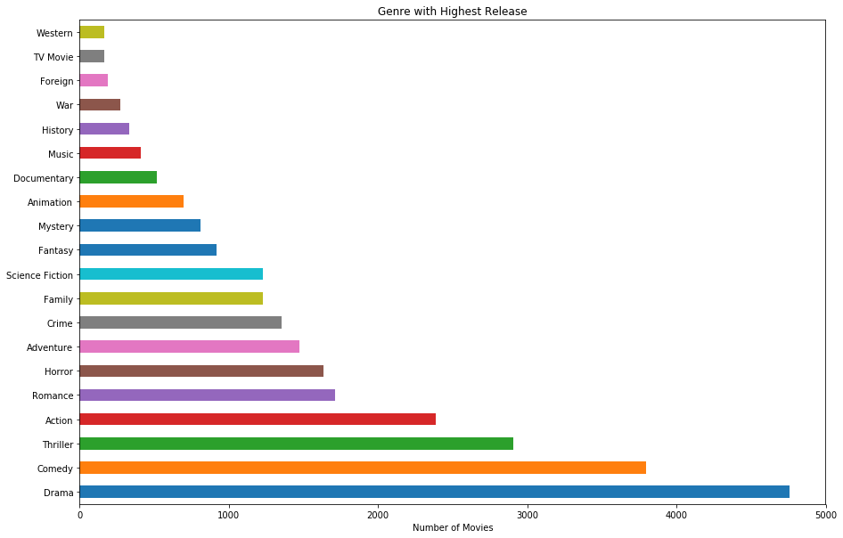

```python
# Plot bar chart for Genre with highest release
plt.figure(figsize = (15,10))
plt.subplot(111)
genres_count.plot(kind = 'barh')
plt.xlabel('Number of Movies')
plt.title('Genre with Highest Release')
plt.show()
```

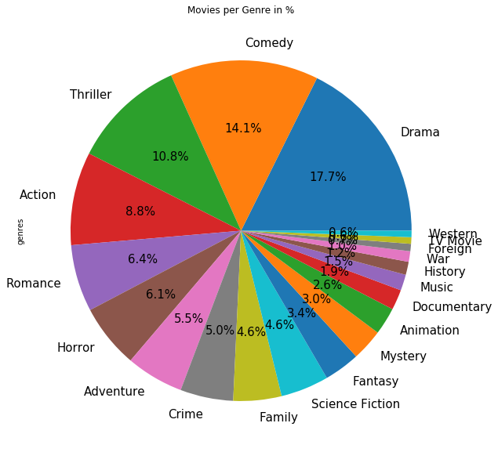

```python
genres_count.plot.pie(title= 'Movies per Genre in %', figsize=(10,10), autopct='%1.1f%%',fontsize=15);
```

##### Production companies with highest release

```python
# Count the movies by production_companies
pro_count = df_split_production_companies.production_companies.value_counts()
pro_count_top20 = pro_count.head(20)
pro_count_top20
```

```
Universal Pictures                        522
Warner Bros.                              509
Paramount Pictures                        431
Twentieth Century Fox Film Corporation    282
Columbia Pictures                         272
New Line Cinema                           219
Metro-Goldwyn-Mayer (MGM)                 218
Walt Disney Pictures                      214
Touchstone Pictures                       178
Columbia Pictures Corporation             160
TriStar Pictures                          147
Miramax Films                             139
Relativity Media                          108
Regency Enterprises                        95
Canal+                                     92
Village Roadshow Pictures                  88
20th Century Fox                           88
DreamWorks SKG                             88
BBC Films                                  87
Dimension Films                            82
Name: production_companies, dtype: int64
```

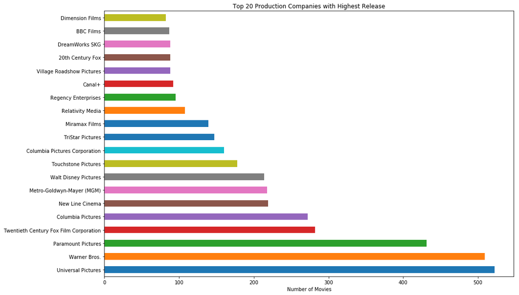

```python
# Plot bar chart for Top 20 most productive production companies
plt.figure(figsize = (15,10))
plt.subplot(111)
pro_count_top20.plot(kind = 'barh')
plt.xlabel('Number of Movies')
plt.title('Top 20 Production Companies with Highest Release')
plt.show()
```

##### Directors with highest release

```python
# Count the movies by directors
director_count = df_split_director.director.value_counts()
director_count_top20 = director_count.head(20)
director_count_top20
```

```
Woody Allen             46
Clint Eastwood          34
Martin Scorsese         31
Steven Spielberg        30
Steven Soderbergh       23
Ridley Scott            23
Ron Howard              22
Joel Schumacher         21
Tim Burton              20
Brian De Palma          20
Robert Rodriguez        19
Francis Ford Coppola    19
Wes Craven              19
John Carpenter          19
David Cronenberg        19
Barry Levinson          19
Rob Reiner              18
Mike Nichols            18
Walter Hill             18
John Landis             18
Name: director, dtype: int64
```

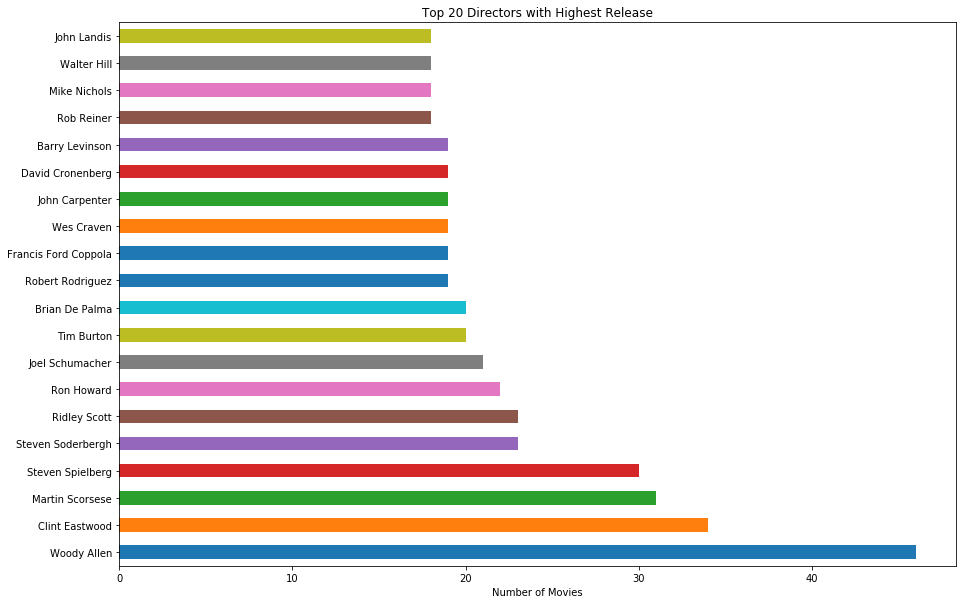

```python
# Plot bar chart for top 20 most productive directors
plt.figure(figsize = (15,10))
plt.subplot(111)
director_count_top20.plot(kind = 'barh')
plt.xlabel('Number of Movies')
plt.title('Top 20 Directors with Highest Release')
plt.show()
```

#### 2. What's the trend of total movie budget over years?

```python
budget_year = df[['budget_adj','release_year']].groupby('release_year').sum()
budget_year
```

| release_year | budget_adj |
| --- | --- |
| 1960 | 1.626252e+08 |
| 1961 | 3.365630e+08 |
| 1962 | 3.944616e+08 |
| 1963 | 5.221334e+08 |
| 1964 | 2.775772e+08 |
| 1965 | 4.858590e+08 |
| 1966 | 3.866540e+08 |
| 1967 | 6.579397e+08 |
| 1968 | 4.509830e+08 |
| 1969 | 2.504264e+08 |
| 1970 | 7.130931e+08 |
| 1971 | 4.092587e+08 |
| 1972 | 1.891804e+08 |
| 1973 | 3.201623e+08 |
| 1974 | 3.403832e+08 |
| 1975 | 2.280324e+08 |
| 1976 | 4.680419e+08 |
| 1977 | 5.813295e+08 |
| 1978 | 6.986145e+08 |
| 1979 | 7.656024e+08 |
| 1980 | 9.591883e+08 |
| 1981 | 8.963425e+08 |
| 1982 | 9.892602e+08 |
| 1983 | 1.136488e+09 |
| 1984 | 1.530647e+09 |
| 1985 | 1.517781e+09 |
| 1986 | 1.401604e+09 |
| 1987 | 1.361503e+09 |
| 1988 | 1.706241e+09 |
| 1989 | 1.899099e+09 |
| 1990 | 2.152749e+09 |
| 1991 | 2.347575e+09 |
| 1992 | 2.240538e+09 |
| 1993 | 2.686296e+09 |
| 1994 | 3.279412e+09 |
| 1995 | 4.100986e+09 |
| 1996 | 5.125788e+09 |
| 1997 | 6.454163e+09 |
| 1998 | 6.019175e+09 |
| 1999 | 7.546997e+09 |
| 2000 | 7.284599e+09 |
| 2001 | 6.947987e+09 |
| 2002 | 7.145845e+09 |
| 2003 | 7.396432e+09 |
| 2004 | 8.277766e+09 |
| 2005 | 8.199242e+09 |
| 2006 | 7.902875e+09 |
| 2007 | 8.030088e+09 |
| 2008 | 7.880759e+09 |
| 2009 | 8.735031e+09 |
| 2010 | 9.355001e+09 |
| 2011 | 8.742180e+09 |
| 2012 | 7.858264e+09 |
| 2013 | 8.645240e+09 |
| 2014 | 7.298716e+09 |
| 2015 | 6.988821e+09 |

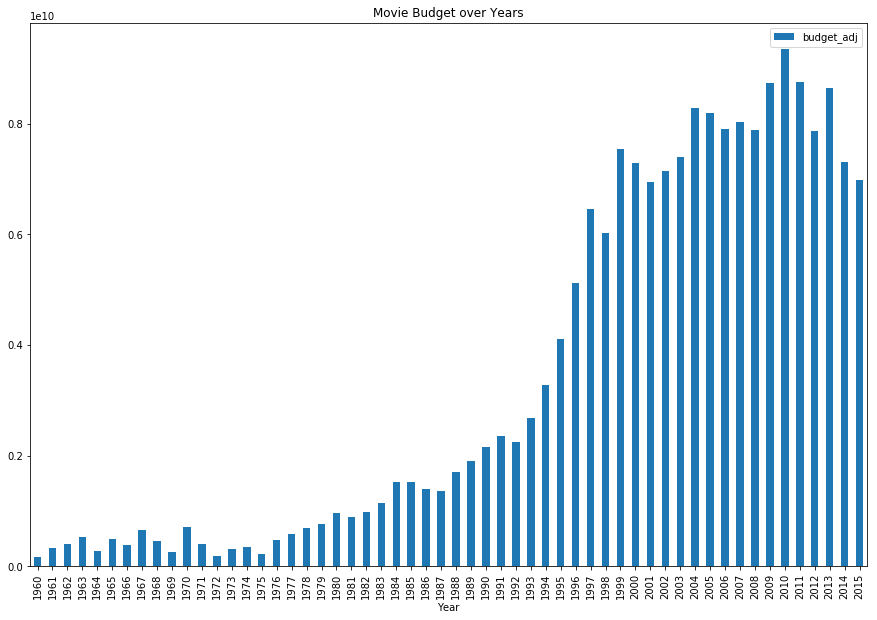

```python
# Plot bar chart for movie budget over years
budget_year.plot(kind = 'bar', figsize = (15,10))
plt.xlabel('Year')
plt.title('Movie Budget over Years')
plt.show()
```

#### 3. What's the trend of total movie revenue over years?

```python
revenue_year = df[['revenue_adj','release_year']].groupby('release_year').sum()
revenue_year.head(20)
```

| release_year | revenue_adj |
| --- | --- |
| 1960 | 1.069117e+09 |
| 1961 | 2.463622e+09 |
| 1962 | 1.553996e+09 |
| 1963 | 1.334357e+09 |
| 1964 | 2.397193e+09 |
| 1965 | 3.170185e+09 |
| 1966 | 5.692623e+08 |
| 1967 | 4.823051e+09 |
| 1968 | 1.659601e+09 |
| 1969 | 1.450145e+09 |
| 1970 | 3.146413e+09 |
| 1971 | 2.180523e+09 |
| 1972 | 2.579801e+09 |
| 1973 | 6.011167e+09 |
| 1974 | 3.593282e+09 |
| 1975 | 3.879578e+09 |
| 1976 | 3.069212e+09 |
| 1977 | 7.845261e+09 |
| 1978 | 4.578763e+09 |
| 1979 | 5.062057e+09 |

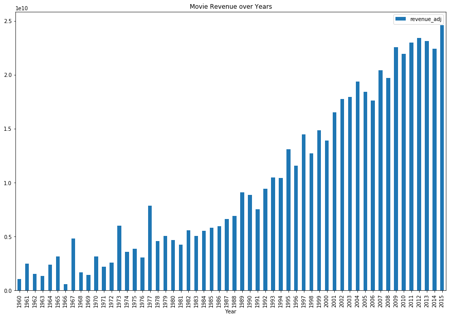

```python
# Plot bar chart for movie Revenue over years
revenue_year.plot(kind = 'bar', figsize = (15,10))
plt.xlabel('Year')
plt.title('Movie Revenue over Years')
plt.show()
```

#### 4. What's the trend of total movie profit over years?

```python
profit_year = df[['profit_adj','release_year']].groupby('release_year').sum()
profit_year.head(20)
```

| release_year | profit_adj |
| --- | --- |
| 1960 | 7.977407e+08 |
| 1961 | 2.181770e+09 |
| 1962 | 1.202945e+09 |
| 1963 | 8.217533e+08 |
| 1964 | 2.071668e+09 |
| 1965 | 2.763256e+09 |
| 1966 | 3.524854e+08 |
| 1967 | 4.159569e+09 |
| 1968 | 1.054890e+09 |
| 1969 | 1.229648e+09 |
| 1970 | 2.550225e+09 |
| 1971 | 1.810959e+09 |
| 1972 | 2.384285e+09 |
| 1973 | 5.194465e+09 |
| 1974 | 2.877058e+09 |
| 1975 | 3.274711e+09 |
| 1976 | 2.411772e+09 |
| 1977 | 6.272042e+09 |
| 1978 | 3.359749e+09 |
| 1979 | 2.855318e+09 |

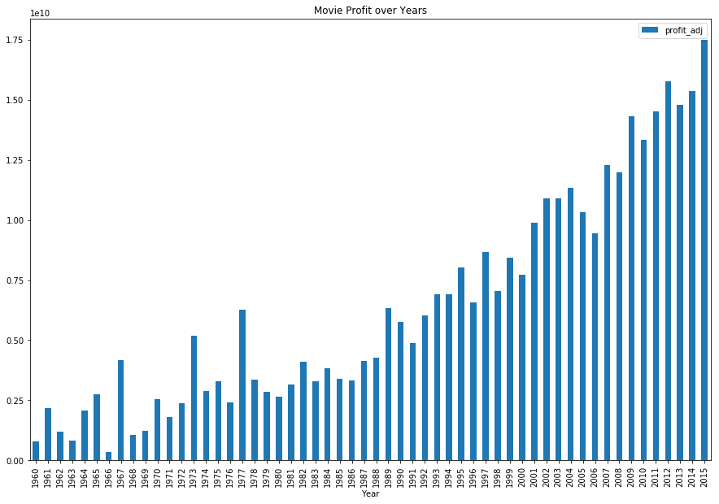

```python
# Plot bar chart for movie Profit over years
profit_year.plot(kind = 'bar', figsize = (15,10))
plt.xlabel('Year')
plt.title('Movie Profit over Years')
plt.show()
```

### Part Two -- Analysis of Categorical Variables:

#### 1. Which genres have the highest popularity/vote-rating/revenue/profit?

This question will be anwsered by computing both the average popularity/vote-rating/revenue/profit per movie and total popularity/vote-rating/revenue/profit of the genres to see if the zero values of revenue and profit could influence the results.

##### Genres with highest popularity

> Popularity per movie

```python
# function of plotting performance per movie
def performance_mean(filename, factor):
    if filename == 'genres':
        per_mean = df_split_genres
    elif filename == 'production_companies':
        per_mean = df_split_production_companies
    elif filename == 'director':
        per_mean = df_split_director
    per_mean = per_mean[[filename,factor]].groupby(filename).mean()
    per_mean = per_mean.sort_values(by=factor, ascending=False).head(20)
    # plot the bar chart
    per_mean.plot(kind = 'bar', figsize = (15,10))
    plt.xlabel(filename)
    plt.ylabel(factor)
    plt.title('Top 20 ' + filename.title() + ' with Highest ' + factor.title() + ' per Movie')
    plt.show()
```

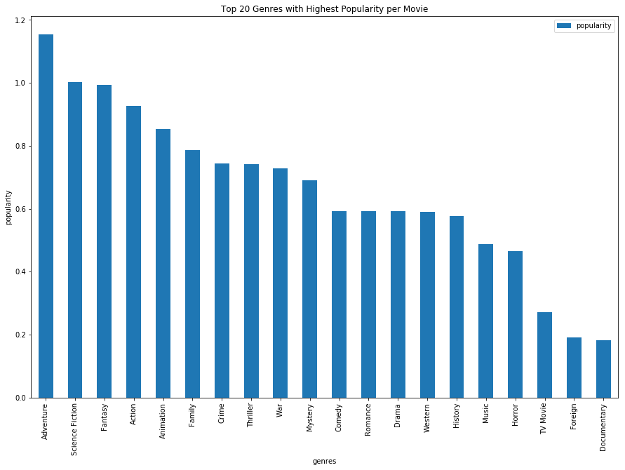

```python
performance_mean('genres', 'popularity')
```

> Total popularity

```python
# function of plotting total performance
def performance_sum(filename, factor):
    if filename == 'genres':
        per_sum = df_split_genres
    elif filename == 'production_companies':
        per_sum = df_split_production_companies
    elif filename == 'director':
        per_sum = df_split_director
    per_sum = per_sum[[filename,factor]].groupby(filename).sum()
    per_sum = per_sum.sort_values(by=factor, ascending=False).head(20)
    # plot the bar chart
    per_sum.plot(kind = 'bar', figsize = (15,10))
    plt.xlabel(filename)
    plt.ylabel(factor)
    plt.title('Top 20 ' + filename.title() + ' with Highest Total ' + factor.title())
    plt.show()
```

[figure not shown]

```python
performance_sum('genres', 'popularity')
```

##### Genres with highest vote-rating

> Vote-rating per movie

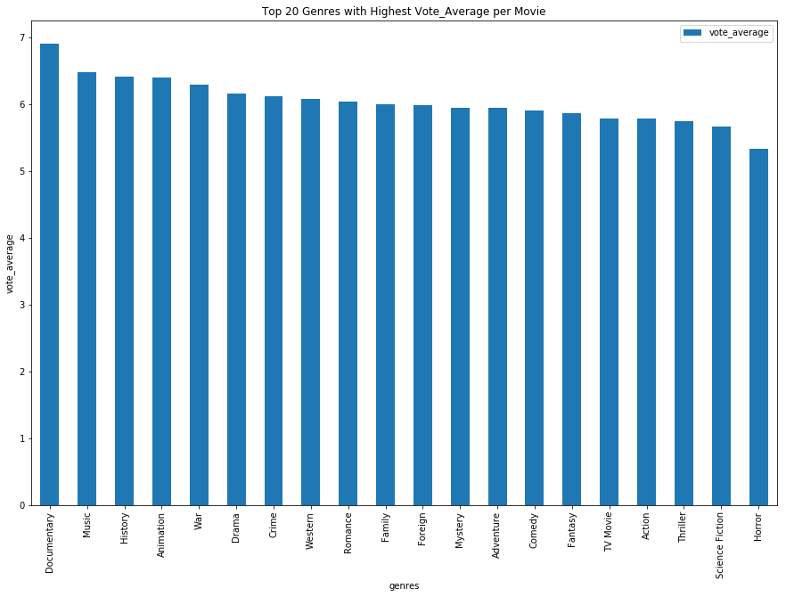

```python
performance_mean('genres', 'vote_average')
```

> Total vote-rating

[figure not shown]

```python
performance_sum('genres', 'vote_average')
```

##### Genres with highest revenue

> Revenue per movie

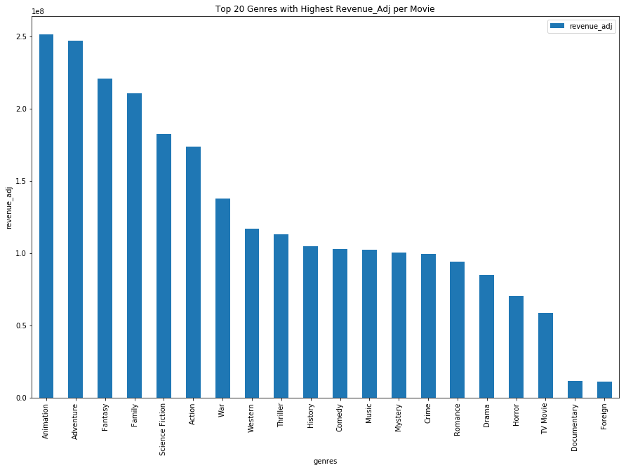

```python
performance_mean('genres', 'revenue_adj')
```

> Total revenue

[figure not shown]

```python
performance_sum('genres', 'revenue_adj')
```

##### Genres with highest profit

> Profit per movie

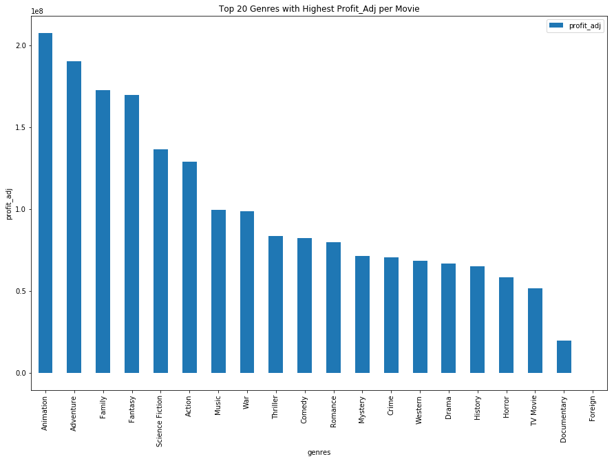

```python
performance_mean('genres', 'profit_adj')
```

> Total profit

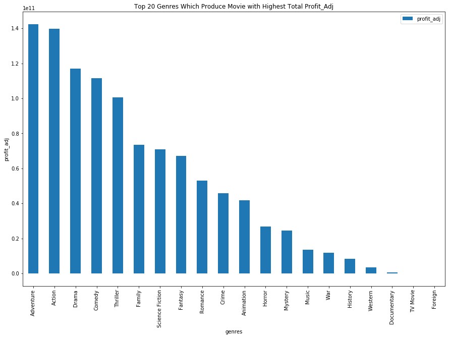

```python
performance_sum('genres', 'profit_adj')
```

#### 2. Which directors direct the movies that have the highest popularity/vote-rating/revenue/profit?

##### Directors whose movies have the highest popularity

> Popularity per movie

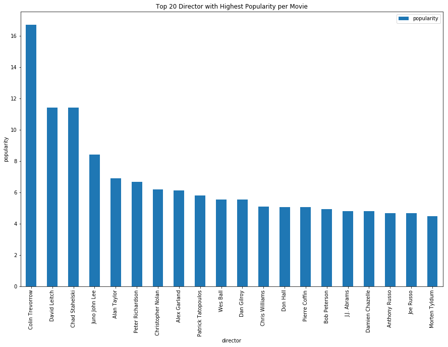

```python
performance_mean('director', 'popularity')
```

> Total Popularity

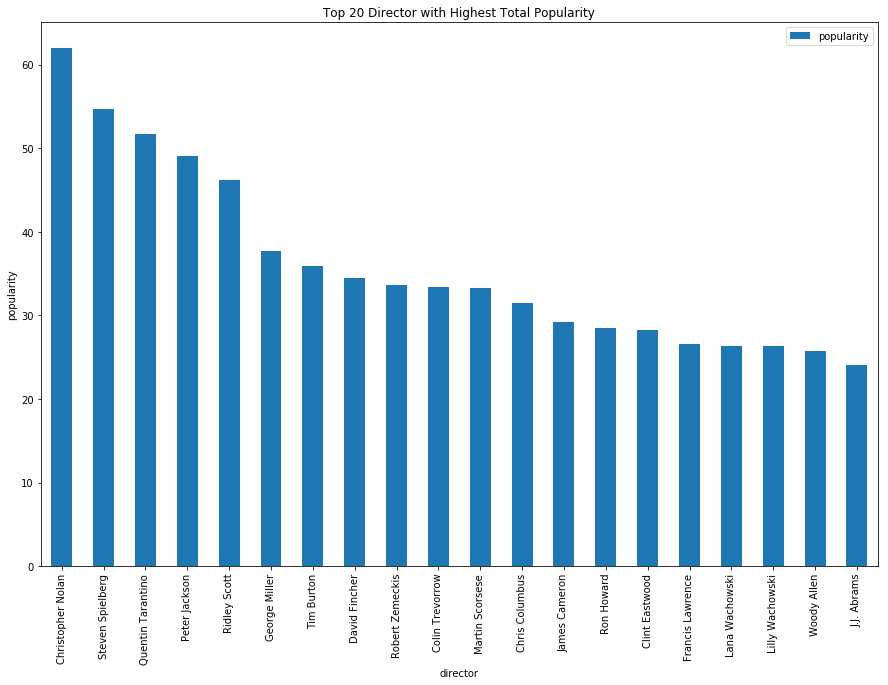

```python
performance_sum('director', 'popularity')
```

##### Directors whose movies have the highest vote-rating

> Vote-rating per movie

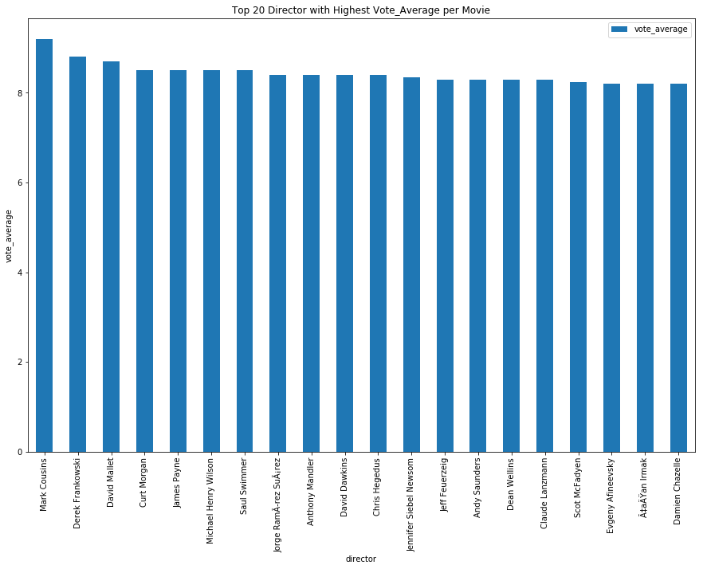

```python
performance_mean('director', 'vote_average')
```

> Total vote-rating

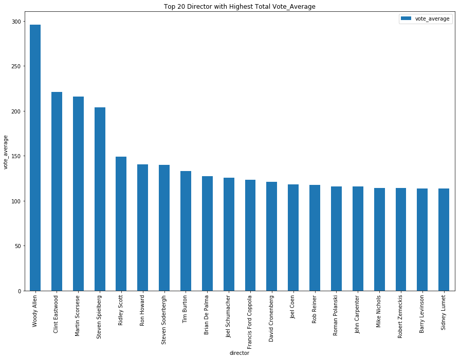

```python
performance_sum('director', 'vote_average')
```

##### Directors whose movies have the highest revenue

> Revenue per movie

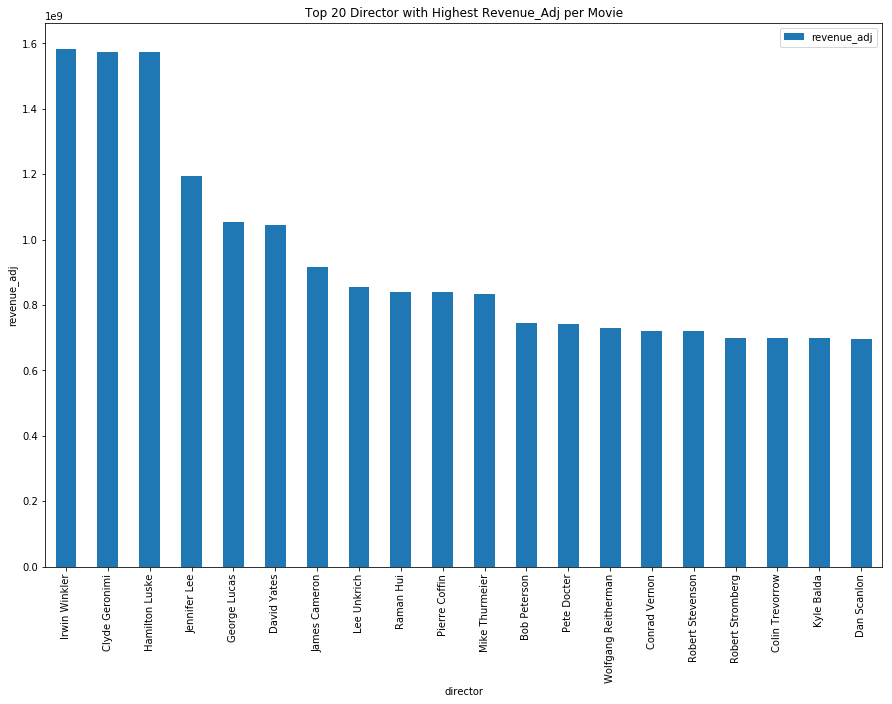

```python
performance_mean('director', 'revenue_adj')
```

> Total revenue

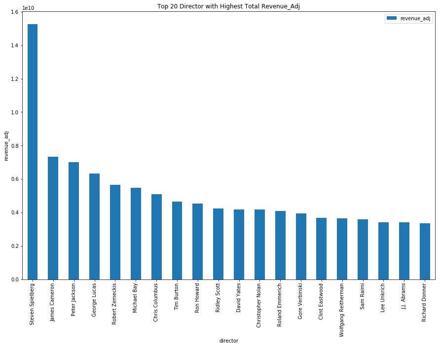

```python
performance_sum('director', 'revenue_adj')
```

##### Directors whose movies have the highest profit

> Profit per movie

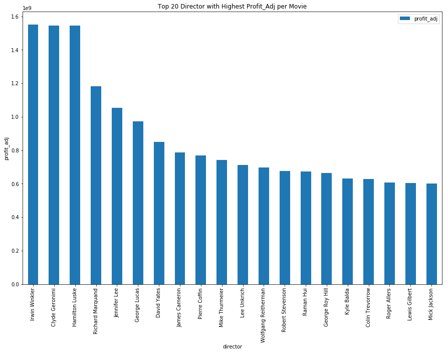

```python
performance_mean('director', 'profit_adj')
```

> Total profit

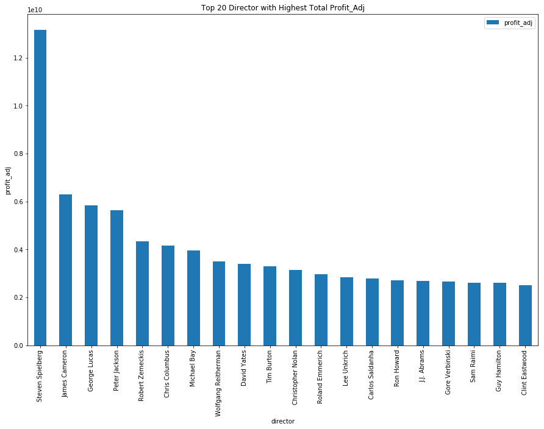

```python
performance_sum('director', 'profit_adj')
```

#### 3. Which Production Companies produce movies that have the highest popularity/vote-rating/revenue/profit?

##### Production companies who produce movies with the highest popularity

> Popularity per movie

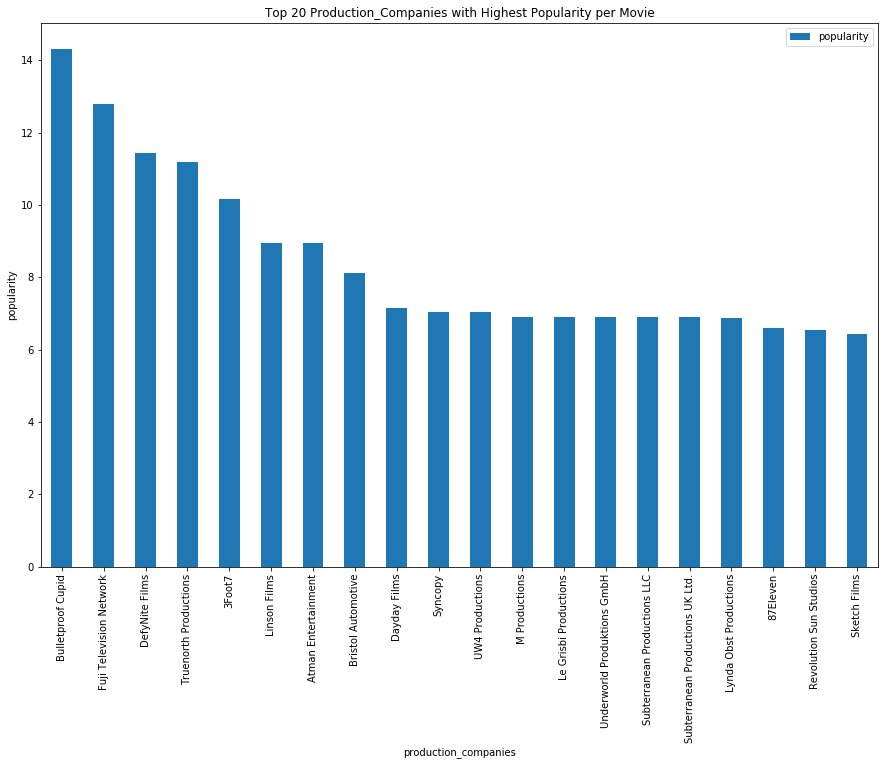

```python
performance_mean('production_companies', 'popularity')
```

> Total popularity

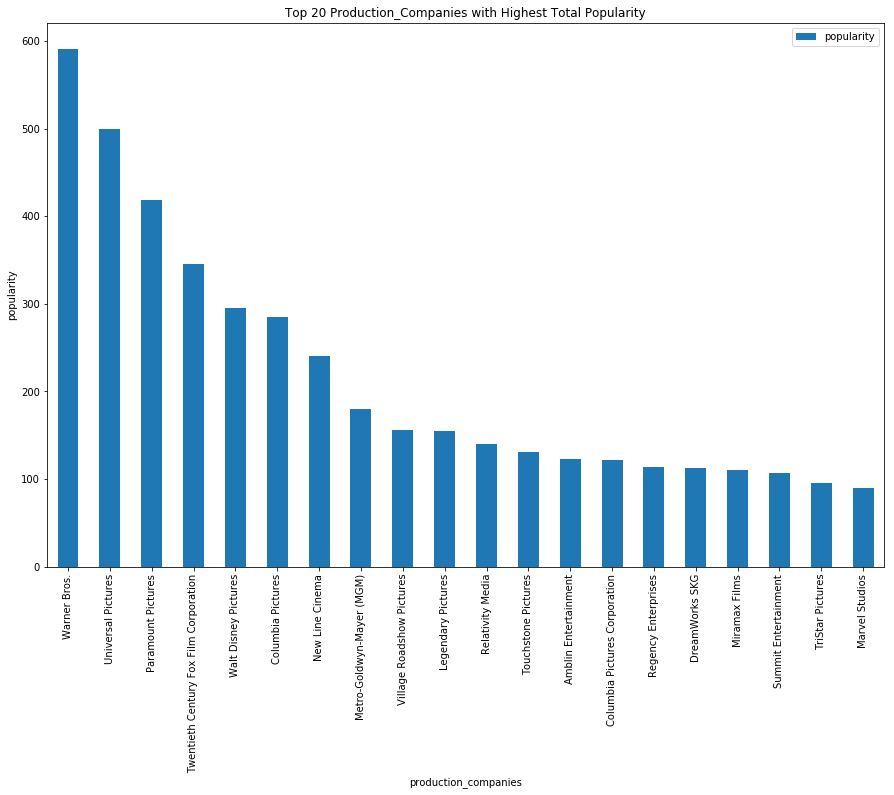

```python
performance_sum('production_companies', 'popularity')
```

##### Production companies who produce movies with the highest vote-rating

> Vote-rating per movie

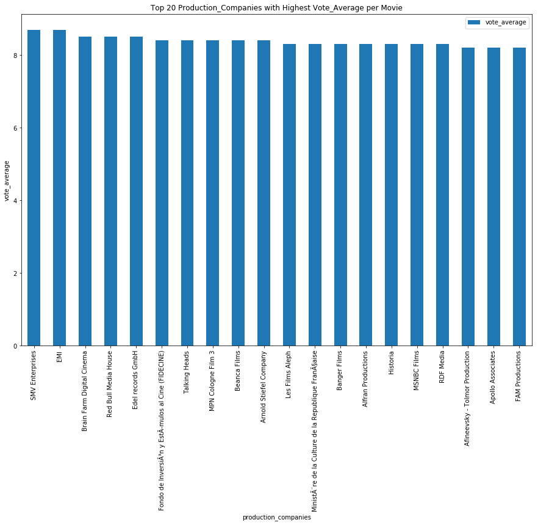

```python
performance_mean('production_companies', 'vote_average')
```

> Total vote-rating

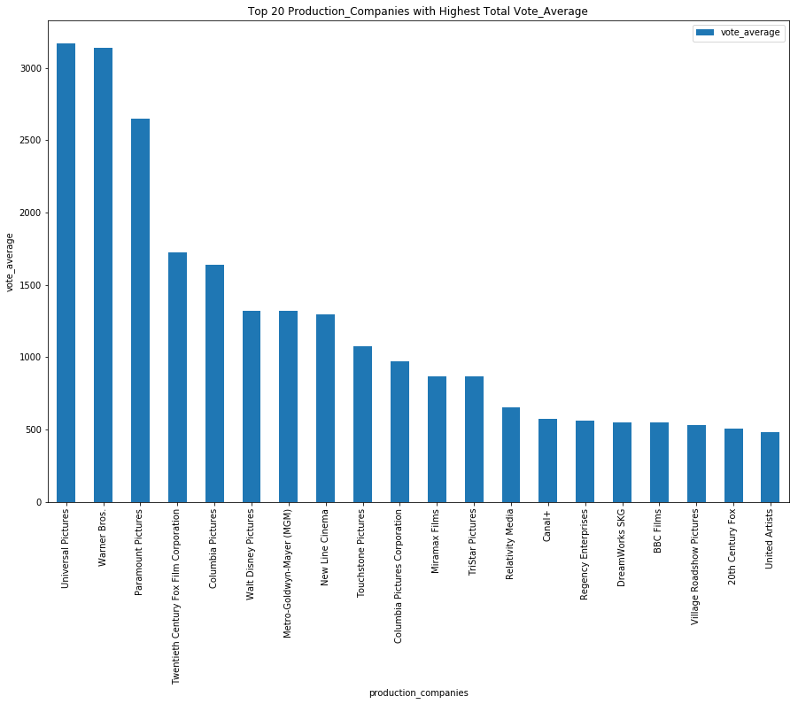

```python
performance_sum('production_companies', 'vote_average')
```

##### Production companies who produce movies with the highest revenue

> Revenue per movie

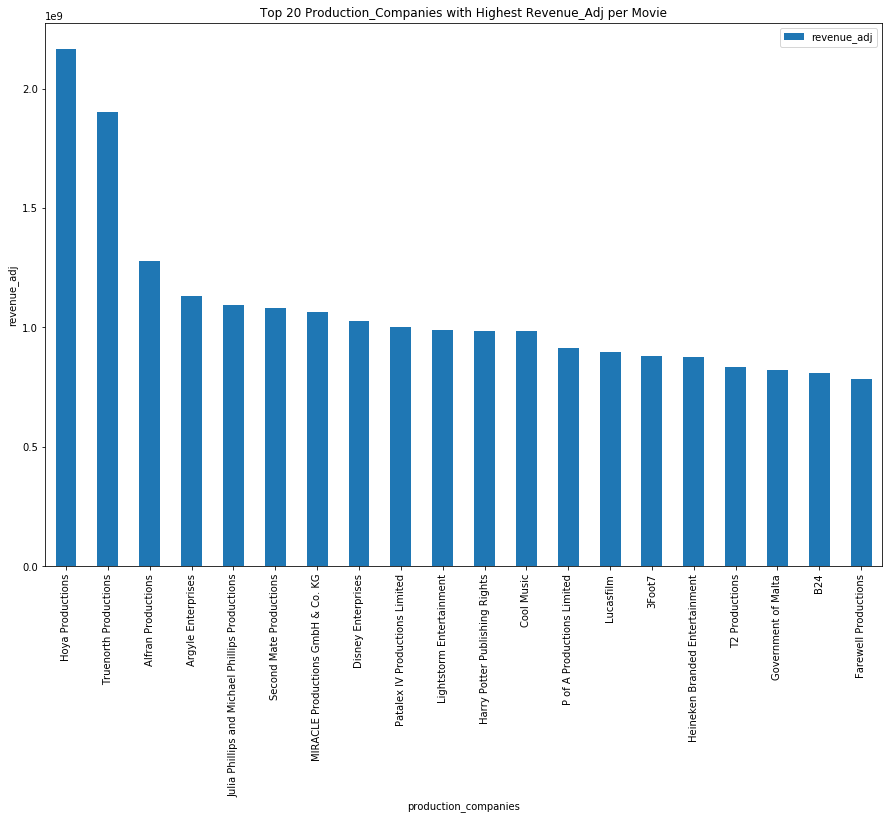

```python
performance_mean('production_companies', 'revenue_adj')
```

> Total revenue

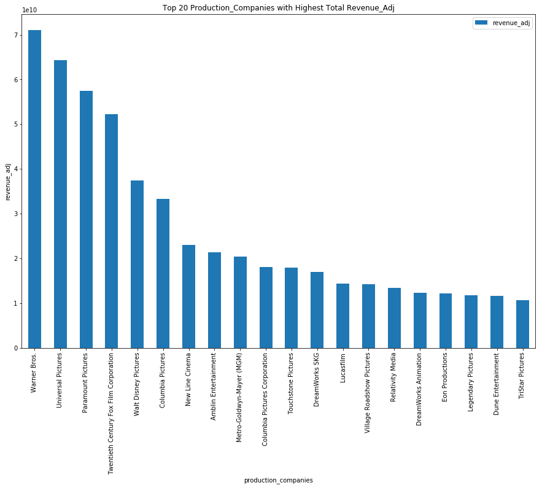

```python
performance_sum('production_companies', 'revenue_adj')
```

##### Production companies who produce movies with the highest profit

> Profit per movie

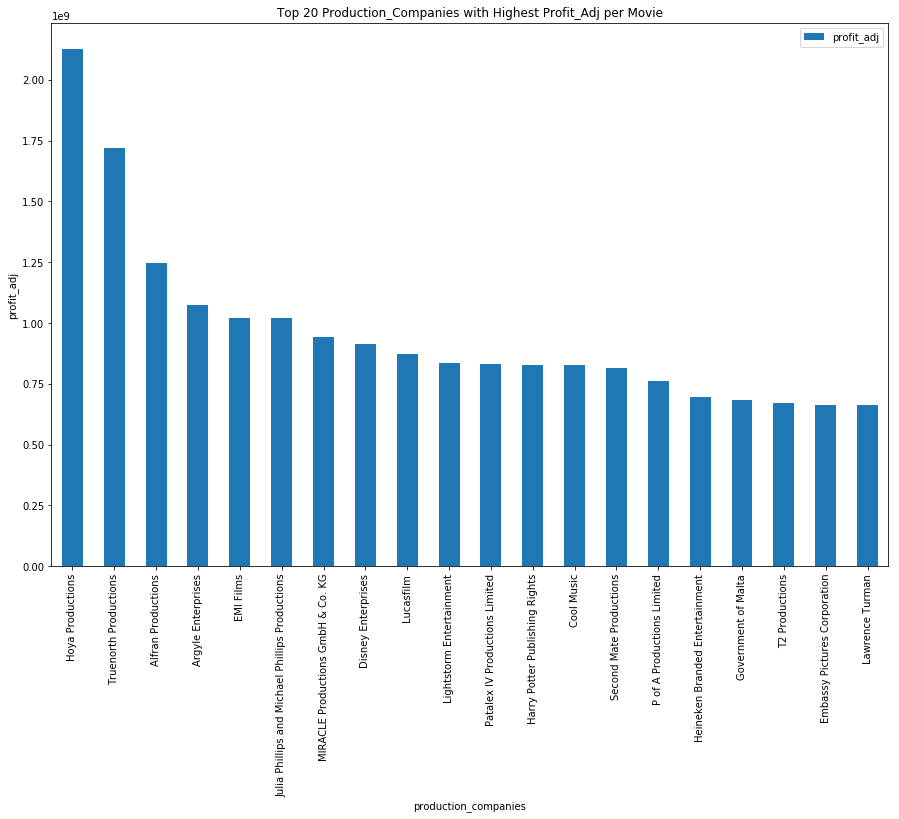

```python
performance_mean('production_companies', 'profit_adj')
```

> Total profit

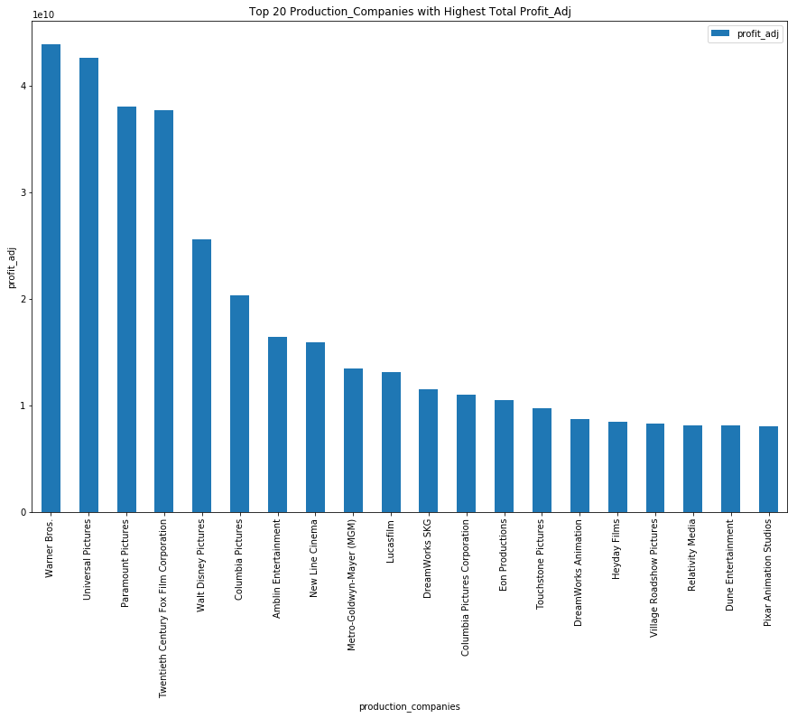

```python
performance_sum('production_companies', 'profit_adj')
```

### Part Three -- Analysis of Numerical Variables:

> 1. What kinds of properties are associated with high revenues?

```python
df.corr()
```

|  | id | popularity | runtime | vote_count | vote_average | release_year | budget_adj | revenue_adj | profit_adj |
| --- | --- | --- | --- | --- | --- | --- | --- | --- | --- |
| id | 1.000000 | -0.014351 | -0.088368 | -0.035555 | -0.058391 | 0.511393 | -0.163046 | -0.115453 | -0.069675 |
| popularity | -0.014351 | 1.000000 | 0.139032 | 0.800828 | 0.209517 | 0.089806 | 0.435336 | 0.561746 | 0.516868 |
| runtime | -0.088368 | 0.139032 | 1.000000 | 0.163273 | 0.156813 | -0.117187 | 0.329215 | 0.263914 | 0.235249 |
| vote_count | -0.035555 | 0.800828 | 0.163273 | 1.000000 | 0.253818 | 0.107962 | 0.523476 | 0.666495 | 0.614062 |
| vote_average | -0.058391 | 0.209517 | 0.156813 | 0.253818 | 1.000000 | -0.117576 | 0.112226 | 0.242319 | 0.288651 |
| release_year | 0.511393 | 0.089806 | -0.117187 | 0.107962 | -0.117576 | 1.000000 | 0.036645 | -0.099447 | -0.132202 |
| budget_adj | -0.163046 | 0.435336 | 0.329215 | 0.523476 | 0.112226 | 0.036645 | 1.000000 | 0.570451 | 0.404344 |
| revenue_adj | -0.115453 | 0.561746 | 0.263914 | 0.666495 | 0.242319 | -0.099447 | 0.570451 | 1.000000 | 0.981854 |
| profit_adj | -0.069675 | 0.516868 | 0.235249 | 0.614062 | 0.288651 | -0.132202 | 0.404344 | 0.981854 | 1.000000 |

According to the correlation matrix above, we can see that out of the properties we are interested in, popularity and budget are moderately associated with revenue. Let's plot the scatter chart to show their relationship.

> Popularity vs. revenue

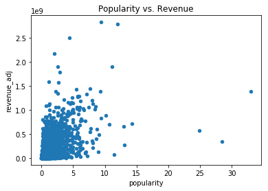

```python
df.plot(x='popularity',y='revenue_adj',kind='scatter', title='Popularity vs. Revenue')
```

> Budget vs. revenue

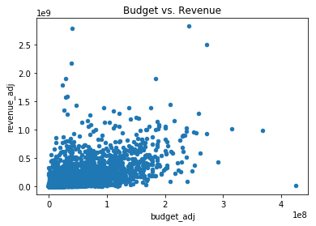

```python
df.plot(x='budget_adj',y='revenue_adj',kind='scatter', title='Budget vs. Revenue')
```

> 1. What kinds of properties are associated with have high profit?

From the correlation matrix above, we can see popularity is moderately associated with profit. A scatter chart is plotted to show their relationship.

> Popularity vs. profit

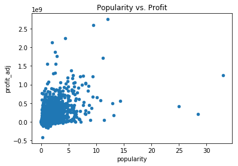

```python
df.plot(x='popularity',y='profit_adj',kind='scatter', title ='Popularity vs. Profit')
```

## Conclusions

The results of this investigation are discussed in the following three parts

### Part One -- Interesting Trends:

#### 1. Which genre/production company/director has the highest release of movies?

> Drama (4760), Comedy (3793), Thriller (2907), Action (2384) and Romance (1712) are the top 5 genres that have the highest release of movies, being produced by the most productive production companies such as Universal Pictures (522), Warner Bros. (509), Paramount Pictures (431), Twentieth Century Fox Film Corporation (282), and Columbia Pictures (272) etc. The most productive directors are Woody Allen (46), Clint Eastwood (34), Martin Scorsese (31), Steven Spielberg (30) and Steven Soderbeigh (23) as the top 5.

#### 2. What's the total budget from year to year?

> The total budget of movies generally increased from year to year, with a rapid rise from 1994 to 1999 and reached the perk in 2010 with around 9.3 billion budget invested.

#### 3. What's the total revenue from year to year?

> The total revenue continuously increased over years and reach its maximum in 2015 at 25 billion.

#### 4. What's the total profit from year to year?

> The total profit of movies has the similar trend as the total revenue and reach the maximum in 2015 at 17.5 billion

### Part Two -- Analysis of Categorical Variables:

> Genre, director, and production company are the three categorical variables we are interested to investigate. We do the analysis one by one and by calculating both the average performance per movie and the total performance.

#### 1. Which genres have the highest popularity/vote-rating/revenue/profit?

> When popularity per movie is calculated, the most popular genres are Adventure, Science Fiction, Fantasy, Action, and Animation. While when the total popularity is calculated, Drama, Comedy, Action, Thriller and Adventure are the top genres. The difference may lies in the high release number of Drama and Comedy despite their relatively low popularity per movie. Documentary, Music, History, Animation, and War are the top 5 genres which have the highest vote-rating per movie. But for total vote-rating, Drama, Comedy, Thriller, Action, and Romance become the top performers due to the large release number. When considering the revenue of individual movie, Animation, Adventure, Fantasy, Family and Science Fiction are the top genres. When it comes to the total revenue, Action, Adventure, Drama, Comedy, and Thriller climb up to the top of the ranking. The result shows that Animation used to be the top-grossing movie, although it has a relatively low release. The chart of profit show the similar result as the chart of revenue. The main difference is that for total revenue, Actions perform better and Adventures, while for total profit, Adventures perform better than Actions. One possible explanation is that the Actions tend to require higher budget than Adventures did.

#### 2. Which directors direct the movies that have the highest popularity/vote-rating/revenue/profit?

> Colin Trevorrow, David Leitch, Chad Stahelski, Juno John Lee and Alan Taylor are the top 5 directors who have the highest popularity per move. For total popularity, the top 5 directors are Christopher Nolan, Steven Spielberg, Quentin Tarantino, Peter Jackson and Ridley Scott. There is no significant difference among directors in terms of vote-rating per movie. For the total vote-rating, Woody Allen performed much better than the others, followed by Clint Eastwood, Martin Scorsese, Steven Spielberg, and Ridley Scott When it comes to revenue, Irwin Winkler, Clyde Geronimi, Hamilton Luske, Jennifer Lee, and George Lucas are the top 5 directors who have the highest revenue per movie. After taking into account the release number of directors, Steven Spielberg, Steven Spielberg performed much better than the other directors. The total revenue of movies directed by him is twice the amount of the second director. The results for profit are almost the same as those for revenue. Thus, we are not going to go through it in detail.

#### 3. Which Production Companies produce movies that have the highest popularity/vote-rating/revenue/profit?

> The analysis of production companies reveals that producers associated with high popularity movies are Warner Bros., Universal Pictures and Paramount Bulletproof Cupid, Fuji Television Network, and DefyNite Films are the producers that have the highest popularity per movie. The vote-ratings per movie are almost the same among producers. For the revenue/profit per movie, Hoya Productions, Truenorth Productions, Alfran Productions are the tops three producers. When the number of release is taken into account, Warner Bros., Universal Pictures, and Paramount Pictures are the top producers for all the four metrics.

### Part Three -- Analysis of Numerical Variables:

#### 1. What kinds of properties are associated with high revenues?

> By calculating the correlation matrix and plotting the scatter chart, we find that popularity and budget are moderately associated with revenue.

#### 2. What kinds of properties are associated with high profit?

> The correlation matrix and scatter chart show that popularity is moderately associated with profit.

## Limitations

> First, the way I deal with inaccurate and unreasonable data can be further discussed. There is a large number of zero values in revenue and budget. I replace them with nulls. However, I randomly picked some of them and searched online, these data are actually available. With these values being rectified, the analysis will be more accurate.

> Second, the lack of information on how popularity and vote-rating were calculated limit the current analysis. Knowing more about how these metrics are calculated can help us make better judgement on when and how to use these data. For example, how to deal with zero values or outliers of them.

> Third, the methods and skills covered by the course so far is very limited, more detailed and advanced analysis are required to reveal more useful and inspiring findings. For example, time series analysis are expected to describe the trends of movie industry, and correlation analysis is needed to show delicate relationship between factors.